# WildCard Results

2024-06-25

# **Participant Information**

**Pre-catch exclusion**

N = 390

| condition | sex | n | age_mean | age_sd | age_median | age_IQR | dur_minutes_mean | dur_minutes_median |
| --- | --- | --- | --- | --- | --- | --- | --- | --- |
| Extreme 1st | Female | 86 | 42.233 | 10.527 | 41 | 15.75 | 25.239 | 22.775 |
| Extreme 1st | Male | 63 | 42.778 | 9.980 | 41 | 15.00 | 25.689 | 22.867 |
| Extreme 2nd | Female | 72 | 44.750 | 11.610 | 46 | 15.75 | 24.641 | 21.483 |
| Extreme 2nd | Male | 44 | 38.955 | 10.764 | 38 | 15.25 | 34.079 | 22.600 |
| No Extreme | Female | 73 | 43.849 | 11.696 | 44 | 19.00 | 23.336 | 21.950 |
| No Extreme | Male | 52 | 41.346 | 12.228 | 38 | 20.25 | 24.293 | 21.708 |

**Post-catch exclusion**

N = 372

| condition | sex | n | age_mean | age_sd | age_median | age_IQR | dur_minutes_mean | dur_minutes_median |
| --- | --- | --- | --- | --- | --- | --- | --- | --- |
| Extreme 1st | Female | 82 | 42.366 | 10.121 | 41.0 | 15.00 | 25.264 | 22.408 |
| Extreme 1st | Male | 59 | 43.034 | 10.215 | 41.0 | 15.50 | 25.746 | 22.867 |
| Extreme 2nd | Female | 71 | 44.958 | 11.557 | 46.0 | 15.50 | 24.650 | 21.483 |
| Extreme 2nd | Male | 41 | 39.634 | 10.839 | 39.0 | 14.00 | 35.061 | 22.950 |
| No Extreme | Female | 68 | 43.706 | 11.722 | 43.5 | 19.25 | 23.119 | 21.817 |
| No Extreme | Male | 51 | 41.255 | 12.332 | 37.0 | 20.50 | 24.380 | 21.717 |

#### Condition totals:

| condition | n | age_mean | age_sd | age_median | age_IQR | dur_minutes_mean | dur_minutes_median |
| --- | --- | --- | --- | --- | --- | --- | --- |
| Extreme 1st | 141 | 42.645 | 10.129 | 41 | 15.0 | 25.466 | 22.767 |
| Extreme 2nd | 112 | 43.009 | 11.541 | 42 | 17.0 | 28.461 | 21.942 |
| No Extreme | 119 | 42.655 | 11.997 | 41 | 20.5 | 23.660 | 21.717 |

**Notes**

- Total number of catch trial exclusions = 18.
- Some participants reported a program crash during the memory phase. Their data is included in the numbers above. For reference:
  - 0 crashed in the first-outcome judgment.
  - 1 crashed in the frequency judgment.

# **Catch Trials**

**Plot - Block means and 95% CIs**

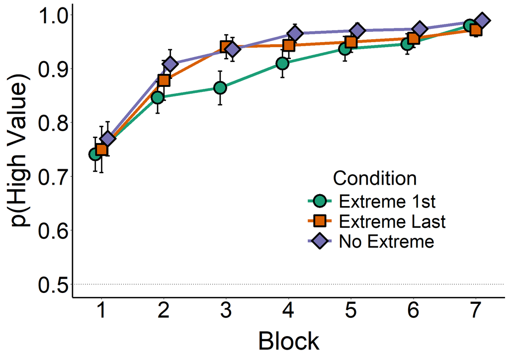

# **Risk-Preference**

**Complications**

**Data is lumpy:**

- There is not a lot of distinction among the measured choice proportions. All of the measurements can be categorized in to just 13 bins (see table below). For future studies, it might be worth adding additional testing trials to obtain a more continuous set of measurements.

| CP | 0 | 0.08 | 0.17 | 0.25 | 0.33 | 0.42 | 0.5 | 0.58 | 0.67 | 0.75 | 0.83 | 0.92 | 1 |
| --- | --- | --- | --- | --- | --- | --- | --- | --- | --- | --- | --- | --- | --- |
| Frequency | 267 | 54.00 | 40.00 | 30.00 | 27.00 | 34.00 | 40.0 | 27.00 | 24.00 | 32.00 | 34.00 | 30.00 | 105 |

**High-value risky choices are bimodal**

- For the high-value choice, most values are either 0 or 1 (see histograms below). This is actually a important aspect of the data that (probably?) hasn’t been noticed/discussed in past extreme-outcome papers. Looking at the means, the high-value choices appear to be around indifference ($\approx 0.46$), but the histograms show that this is an artifact of the aggregation.
- At the level of the individual, most participants either completely prefer the fixed alternative or completely prefer the risky alternative with some in between. Statistically, it’s not clear what the best way to handle this fact given the between- and within- subject manipulations. In any case, it’s probably worth pointing out to the readers that the mean proportion for the high-value choices is not really describing the individual data all that accurately. **i.e., The population is indifferent; however, the individuals are not (generally speaking).**

**Low-value choices are heavily skewed**

- By and large participants are only choosing the fixed option, creating very heavy skew. Consequently, people are much more risk-averse in the low-value context than the means would suggest they are (compare the low value mean vs median choice proportions in the summary stat table).

**Classic ANOVA is probably inadequate**

- A conventional ANOVA does not model this data very well. Note the non-normal residuals in the Q-Q plot below (from the ANOVA run on the differences). The pre-registration document calls for three separate ANOVAs, which are provided below. However, given the residuals, it’s probably not wise to rely on a conventional ANOVA methodology. i.e., one based around ordinary least-squares (OLS). Consequently, an ANOVA using generalized least-squares (GLS) fit by maximum likelihood has been applied.
- In addition to the three one-way ANOVAs declared in the pre-registration document, a 2x3 ANOVA using a linear mixed effects (LME) models fit by maximum likelihood has been run - because it seems like the more elegant way to approach this particular experimental design which has both between- and within- subjects factors.
- Having said all that, no matter what approach you take (OLS, GLS, or LME), you will end up drawing the same conclusions. Though, the 2x3 LME approach seems the most elegant way of arriving at them and will probably read the best in the manuscript.

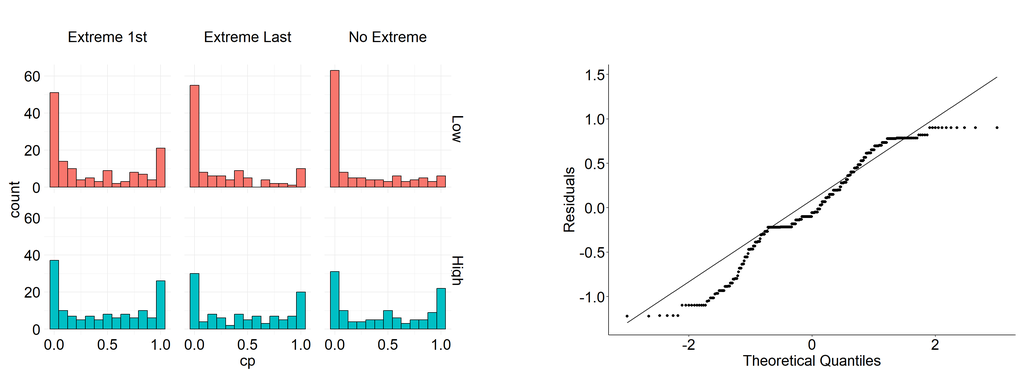

**Plot - Block means and 95% CIs**

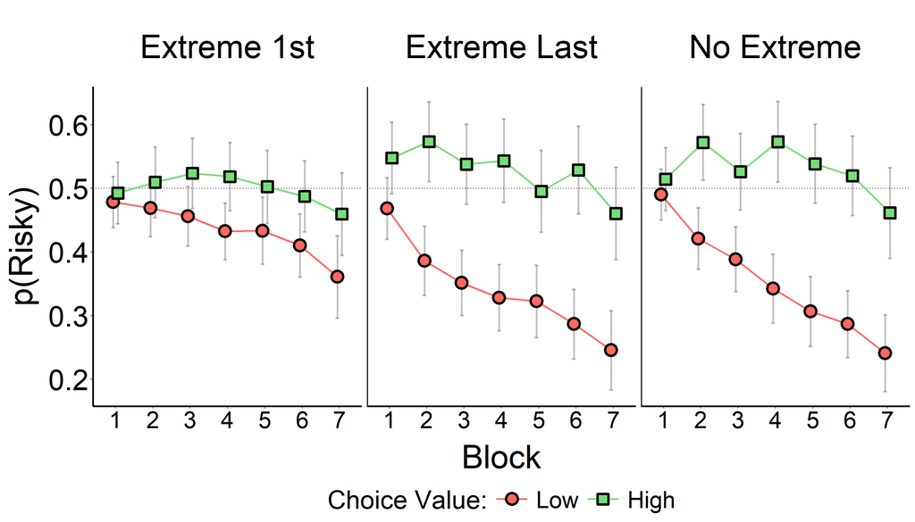

**Summary Statistics (Block 7)**

| condition | risky_choice | n | mean | sd | median | IQR |
| --- | --- | --- | --- | --- | --- | --- |
| Extreme 1st | Low | 141 | 0.361 | 0.390 | 0.167 | 0.750 |
| Extreme 1st | High | 141 | 0.460 | 0.391 | 0.417 | 0.833 |
| Extreme Last | Low | 112 | 0.246 | 0.332 | 0.083 | 0.417 |
| Extreme Last | High | 112 | 0.461 | 0.388 | 0.417 | 0.833 |
| No Extreme | Low | 119 | 0.241 | 0.333 | 0.000 | 0.458 |
| No Extreme | High | 119 | 0.461 | 0.393 | 0.500 | 0.917 |

## Pre-Registered Analysis

**One-Way ANOVA on Difference (High - Low)**

#### Main Effect

|  | numDF | F-value | p-value | pseudo_R2 |
| --- | --- | --- | --- | --- |
| (Intercept) | 1 | 38.329 | 0.000 | NA |
| condition | 2 | 2.151 | 0.118 | 0.014 |
| Residuals | 369 | NA | NA | NA |

**Effect of Condition:**

$F(2, 369) = 2.15, p = 0.118, R^2_N = 0.01$

#### Planned Contrasts

|  | Value | Std.Error | t-value | p-value | sig | DF | r_effect |
| --- | --- | --- | --- | --- | --- | --- | --- |
| (Intercept) | 0.221 | 0.049 | 4.472 | 0.000 | TRUE | 369 | 0.227 |
| conditionE1_v_NE | -0.122 | 0.067 | -1.820 | 0.070 | FALSE | 369 | 0.094 |
| conditionE2_v_NE | -0.006 | 0.071 | -0.078 | 0.937 | FALSE | 369 | 0.004 |

**Extreme First vs. No Extreme:**

$b = -0.12, t(369) = -1.82, p = 0.07, r = 0.094$

**Extreme Last vs. No Extreme:**

$b = -0.01, t(369) = -0.08, p = 0.937, r = 0.004$

#### Post-Hoc Pairwise Comparisons

|  | psihat | ci.lower | ci.upper | p.value |
| --- | --- | --- | --- | --- |
| Extreme 1st-Extreme Last | -0.116 | -0.285 | 0.053 | 0.202 |
| Extreme 1st-No Extreme | -0.122 | -0.279 | 0.036 | 0.197 |
| Extreme Last-No Extreme | -0.006 | -0.166 | 0.155 | 0.934 |

**One-Way ANOVA on High Value Choices**

#### Main Effect

|  | numDF | F-value | p-value | pseudo_R2 |
| --- | --- | --- | --- | --- |
| (Intercept) | 1 | 516.849 | 0.000 | NA |
| condition | 2 | 0.001 | 0.999 | 0 |
| Residuals | 369 | NA | NA | NA |

**Effect of Condition:**

$F(2, 369) = 0, p = 0.999, R^2_N = 0$

#### Planned Contrasts

|  | Value | Std.Error | t-value | p-value | sig | DF | r_effect |
| --- | --- | --- | --- | --- | --- | --- | --- |
| (Intercept) | 0.461 | 0.036 | 12.884 | 0.000 | TRUE | 369 | 0.557 |
| conditionE1_v_NE | -0.002 | 0.049 | -0.034 | 0.973 | FALSE | 369 | 0.002 |
| conditionE2_v_NE | -0.001 | 0.051 | -0.018 | 0.986 | FALSE | 369 | 0.001 |

**Extreme First vs. No Extreme:**

$b = -0.002, t(369) = -0.03, p = 0.973, r = 0.002$

**Extreme Last vs. No Extreme:**

$b = -0.001, t(369) = -0.02, p = 0.986, r = 0.001$

#### Post-Hoc Pairwise Comparisons

|  | psihat | ci.lower | ci.upper | p.value |
| --- | --- | --- | --- | --- |
| Extreme 1st-Extreme Last | -0.001 | -0.119 | 0.117 | 0.988 |
| Extreme 1st-No Extreme | -0.002 | -0.118 | 0.115 | 0.988 |
| Extreme Last-No Extreme | -0.001 | -0.124 | 0.122 | 0.988 |

**One-Way ANOVA on Low Value Choices**

#### Main Effect

|  | numDF | F-value | p-value | pseudo_R2 |
| --- | --- | --- | --- | --- |
| (Intercept) | 1 | 243.860 | 0.000 | NA |
| condition | 2 | 4.824 | 0.009 | 0.047 |
| Residuals | 369 | NA | NA | NA |

**Effect of Condition:**

$F(2, 369) = 4.82, p = 0.009, R^2_N = 0.05$

#### Planned Contrasts

|  | Value | Std.Error | t-value | p-value | sig | DF | r_effect |
| --- | --- | --- | --- | --- | --- | --- | --- |
| (Intercept) | 0.241 | 0.033 | 7.391 | 0.000 | TRUE | 369 | 0.359 |
| conditionE1_v_NE | 0.120 | 0.044 | 2.716 | 0.007 | TRUE | 369 | 0.140 |
| conditionE2_v_NE | 0.005 | 0.047 | 0.099 | 0.921 | FALSE | 369 | 0.005 |

**Extreme First vs. No Extreme:**

$b = 0.12, t(369) = 2.72, p = 0.007, r = 0.14$

**Extreme Last vs. No Extreme:**

$b = 0, t(369) = 0.1, p = 0.921, r = 0.005$

#### Post-Hoc Pairwise Comparisons

|  | psihat | ci.lower | ci.upper | p.value |
| --- | --- | --- | --- | --- |
| Extreme 1st-Extreme Last | 0.116 | 0.007 | 0.224 | 0.023 |
| Extreme 1st-No Extreme | 0.120 | 0.013 | 0.227 | 0.023 |
| Extreme Last-No Extreme | 0.005 | -0.100 | 0.109 | 0.916 |

**Notes**

- E1 = Extreme First; E2 = Extreme Last; NE = No Extreme
- ANOVAs were run using generalized least-squares fit by maximum likelihood.
- $R^2_N$ is Nagelkerke’s (also known as Cragg and Uhler’s) pseudo $R^2$ (Nagelkerke, 1991). It isn’t interpreted in exactly the same way as a $R^2$ based on ordinary least-squares regression, but it is bounded by 0 and 1 and higher values indicate a better model fit.
- $\hat{\Psi}$ is the difference between condition means.
- The post-hoc tests don’t assume equal variance, but do assume normality.
- The Hochberg correction (Hochberg, 1988) was applied to protect family-wise error rate, but others like Holm’s or Benjamini & Hochberg’s could be used instead.

## Alternative Analysis

**2x3 ANOVA using linear mixed-effects models fit by maximum likelihood**

#### Main Effects

|  | Model | df | AIC | BIC | logLik | Test | L.Ratio | p.value | pseudo_R2 | BF_10 |
| --- | --- | --- | --- | --- | --- | --- | --- | --- | --- | --- |
| base | 1 | 4 | 695.483 | 713.932 | -343.742 |  | NA | NA | NA | NA |
| cond_mod | 2 | 6 | 695.425 | 723.098 | -341.713 | 1 vs 2 | 4.058 | 0.131 | 0.009 | 0.010 |
| HL_mod | 3 | 7 | 658.611 | 690.895 | -322.306 | 2 vs 3 | 38.814 | 0.000 | 0.085 | 9831716.987 |
| int_mod | 4 | 9 | 658.125 | 699.633 | -320.062 | 3 vs 4 | 4.486 | 0.106 | 0.010 | 0.013 |

**Main Effect of Condition:**

$\chi^2(2) = 4.06, p = 0.131, R^2_N = 0.01, BF_{10} = 0.01$

**Main Effect of Context / Value (high vs. low):**

$\chi^2(1) = 38.81, p = < 0.001, R^2_N = 0.08, BF_{10} > 150$

**Interaction:**

$\chi^2(2) = 4.49, p = 0.106, R^2_N = 0.01, BF_{10} = 0.013$

#### Planned Contrasts

|  | Value | Std.Error | DF | t-value | p-value | r_effect |
| --- | --- | --- | --- | --- | --- | --- |
| (Intercept) | 0.351 | 0.024 | 369 | 14.504 | 0.000 | 0.603 |
| conditionE1_v_NE | 0.059 | 0.033 | 369 | 1.803 | 0.072 | 0.093 |
| conditionE2_v_NE | 0.002 | 0.035 | 369 | 0.053 | 0.957 | 0.003 |
| risky_choice1 | 0.110 | 0.024 | 369 | 4.555 | 0.000 | 0.231 |
| conditionE1_v_NE:risky_choice1 | -0.061 | 0.033 | 369 | -1.854 | 0.065 | 0.096 |
| conditionE2_v_NE:risky_choice1 | -0.003 | 0.035 | 369 | -0.080 | 0.936 | 0.004 |

**Extreme First vs. No Extreme:**

$b = 0.059, t(369) = 1.8, p = 0.072, r = 0.093$

**Extreme Last vs. No Extreme:**

$b = 0.002, t(369) = 0.05, p = 0.957, r = 0.003$

**Extreme First vs. No Extreme | Context (High vs. Low):**

$b = -0.061, t(369) = -1.85, p = 0.065, r = 0.096$

**Extreme Last vs. No Extreme | Context (High vs. Low):**

$b = -0.003, t(369) = -0.08, p = 0.936, r = 0.004$

**Notes**

- E1 = Extreme First; E2 = Extreme Last; NE = No Extreme
- $R^2_N$ is Nagelkerke’s (also known as Cragg and Uhler’s) pseudo $R^2$ (Nagelkerke, 1991). It isn’t interpreted in exactly the same way as a $R^2$ based on ordinary least-squares regression, but it is bounded by 0 and 1 and higher values indicate a better model fit.
- Bayes Factors are reported as Inverse Bayes Factors, this means larger values indicate greater support for the effect. Anything less than 1 should be considered as contributing no evidence.

# **First-Outcome Judgement**

**Complications**

The pre-registration document states . . .

- *The first-outcome memory tests will be analyzed with a sequence of three McNemar Tests.* **Each test will compare two of the groups and the proportion reporting the extreme option for the high- and low-value option.** *The target prediction of the Encoding Hypothesis is that the proportion of extreme outcomes reported first will be reliably lower in the Extreme First group. Ideally, we would run one test with all three groups (like an overall ANOVA), but as of the time of writing this pre-registration, we have not been able to identify the appropriate variation of a chi-squared test that would work for this scenario.*

Based on this, it seems that the plan was to use McNemar Tests for condition comparisons, doing so three times to compare each pair of conditions (E1 vs EL, E1 vs NE, EL vs NE), while also factoring in counts/proportions for the 20th and 80th extremes. It is not clear that there is a way to do that with this test. You can do one McNemar Test for each condition (which is what has been done below), but you cannot compare across conditions, like is stated in the pre-registration document.

**Alternative to McNemar tests:**

An alternative method to obtain a comparison across conditions could be to run two standard Pearson’s Chi-squared tests using a 3 x 2 contingency table for the the High and Low choices respectively, like so…

|  | High.Extreme | Other |
| --- | --- | --- |
| Extreme First | a | b |
| Extreme Last | c | d |
| No Extreme | e | f |

|  | Low.Extreme | Other |
| --- | --- | --- |
| Extreme First | a | b |
| Extreme Last | c | d |
| No Extreme | e | f |

This would tell you whether reporting the extreme option varied according to condition, and then you could look at the standardized residuals to see where a difference is happening. Or you could do pairwise tests with appropriate p-value adjustments.

**Plot - Proportions**

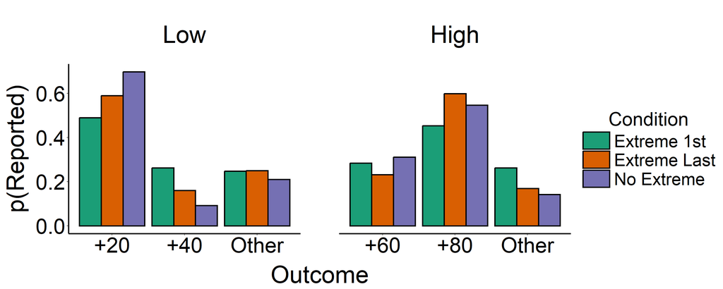

Note:

- Proportions are taken within condition and context (high/low). E.g., All the green bars on the left side sum to 1, all the green bars on the right side sum to one, and so on.
- The colour palette is colourblind friendly.

## Pre-Registered Analysis

**McNemar Test Results**

| Condition | Statistic | df | p.value | OR | Cohen_g | lower_g_ci | upper_g_ci |
| --- | --- | --- | --- | --- | --- | --- | --- |
| Extreme 1st | 0.471 | 1 | 0.493 | 0.889 | -0.029 | -0.112 | 0.055 |
| Extreme Last | 3.903 | 1 | 0.048 | 1.460 | 0.093 | -0.001 | 0.188 |
| No Extreme | 8.327 | 1 | 0.004 | 1.810 | 0.144 | 0.048 | 0.238 |

Effect Size Interpretation

|  | Small | Medium | Large |
| --- | --- | --- | --- |
| Cohen’s g | 0.05 : 0.15 | 0.15 : 0.25 | ≥ 0.25 |
| Odds Ratio > 1 | 1.22 : 1.86 | 1.86 : 3.00 | ≥ 3.00 |
| Odds Ratio < 1 | 0.820 : 0.538 | 0.538 : 0.333 | ≤ 0.333 |

Note:

- Report either the odds ratio or Cohen’s $g$, not both.
- Almost nobody has heard of Cohen’s $g$ and wouldn’t know how to interpret it. Furthermore, they would probably confuse it with Hedge’s $g$ (which is a variant of Cohen’s $d$). Therefore, it’s probably best to report the odds ratio.

**McNemar Test Conclusions**

#### Extreme First Condition:

|  | No | Yes |
| --- | --- | --- |
| High | 77 | 64 |
| Low | 72 | 69 |

$\chi^2(1) = 0.47, p = 0.493$

- There is no significant change in judgement evaluation between the high and low risky doors.
- The odds of getting the judgement correct given they are seeing the high-risk door is 0.89 times that of seeing the low-risk door and getting it wrong.

#### Extreme Last Condition:

|  | No | Yes |
| --- | --- | --- |
| High | 45 | 67 |
| Low | 46 | 66 |

$\chi^2(1) = 3.9, p = 0.048$

- There is a significant change in judgement evaluation between the high and low risky doors.
- The odds of getting the judgement correct given they are seeing the high-risk door is 1.46 times that of seeing the low-risk door and getting it wrong.

#### No Extreme Condition:

|  | No | Yes |
| --- | --- | --- |
| High | 54 | 65 |
| Low | 36 | 83 |

$\chi^2(1) = 8.33, p = 0.004$

- There is a significant change in judgement evaluation between the high and low risky doors.
- The odds of getting the judgement correct given they are seeing the high-risk door is 1.81 times that of seeing the low-risk door and getting it wrong.

## Alternative Analysis

**2x3 Chi-Squared Tests**

#### High Value Results

High Value Contingency Table

|  | No | Yes |
| --- | --- | --- |
| Extreme 1st | 77 | 64 |
| Extreme Last | 45 | 67 |
| No Extreme | 54 | 65 |

$\chi^2(2) = 5.48, p = 0.065, \varphi_c = 0.12$

- Cannot rule out that condition is independent of recalling the extreme value.

Standardized Residuals

|  | No | Yes |
| --- | --- | --- |
| Extreme 1st | 2.20 | -2.20 |
| Extreme Last | -1.81 | 1.81 |
| No Extreme | -0.51 | 0.51 |

p-values

|  | No | Yes |
| --- | --- | --- |
| Extreme 1st | 0.028 | 0.028 |
| Extreme Last | 0.071 | 0.071 |
| No Extreme | 0.608 | 0.608 |

Only the *Extreme 1st* condition differs significantly from the expected value. The *Extreme 1st* condition tends to not recall the extreme value.

- Extreme 1st: $z = -2.2, p = 0.028$

#### Low Value Results

Low Value Contingency Table

|  | No | Yes |
| --- | --- | --- |
| Extreme 1st | 72 | 69 |
| Extreme Last | 46 | 66 |
| No Extreme | 36 | 83 |

$\chi^2(2) = 11.53, p = 0.003, \varphi_c = 0.18$

- Condition is not independent of recalling the extreme value; however, the association/effect is a weak/small one.

Standardized Residuals

|  | No | Yes |
| --- | --- | --- |
| Extreme 1st | 2.96 | -2.96 |
| Extreme Last | -0.08 | 0.08 |
| No Extreme | -2.99 | 2.99 |

p-values

|  | No | Yes |
| --- | --- | --- |
| Extreme 1st | 0.003 | 0.003 |
| Extreme Last | 0.933 | 0.933 |
| No Extreme | 0.003 | 0.003 |

The *Extreme 1st* and *No Extreme* conditions both differ significantly from the expected value. *Extreme 1st* tends to not recall the extreme value, whereas the *No Extreme* does.

- Extreme 1st: $z = -2.96, p = 0.003$
- No Extreme: $z = 2.99, p = 0.003$

Note:

- In the contingency tables, ‘Yes’ indicates the extreme value was recalled, ‘No’ indicates that it was not.
- $\varphi_c$ is Cramér’s V, a measure of association for two nominal variables (i.e., an effect size of sorts). It can take a value between 0 and 1, with 0 indicating no association (i.e., full independence).
- Post-hoc analysis was conducted by evaluating the standardized residuals from the chi-square analysis because it seemed the most intuitive approach. However, another approach would be to conduct pairwise Pearson Chi-squared or Fisher Exact tests across the three conditions.

# **Frequency Judgement**

**Complications**

It seems debatable whether the frequency judgement data should be plotted and analysed using means. The data is almost certainly *qualitative* in nature. For example, there is no reason to assume one person’s judgment of 50% is the same as another person’s. One person’s 50% might be another’s 70%. It is worth remembering **each participant is not providing a objectively measurable frequency, they are giving their opinion about what they believe real frequency is (i.e., it is subjective not objective).**

While the frequency judgement data has been plotted and analysed with means to remain consistent with the prior extreme-outcome work, there is a good argument that this data should be treated as nominal - similar to the first-outcome results (some might wonder why the two are being treated differently). Admittedly, many (in Psychology) would probably argue this data is “sufficiently” quantitative given its wide sample space. Others might argue that it is qualitative, but ordinal (not nominal) and a Kruskal–Wallis test should be used.

**Plot - Means and 95% CIs**

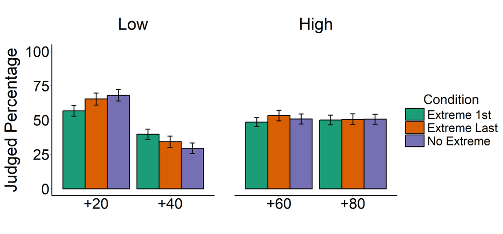

**Table - Plotting Values**

| context | outcome | condition | n | mean | sd | median | IQR |
| --- | --- | --- | --- | --- | --- | --- | --- |
| Low | +20 | Extreme 1st | 141 | 56.759 | 23.962 | 55 | 35.00 |
| Low | +20 | Extreme Last | 112 | 65.348 | 23.394 | 70 | 30.00 |
| Low | +20 | No Extreme | 118 | 68.051 | 23.352 | 70 | 40.00 |
| Low | +40 | Extreme 1st | 141 | 39.695 | 22.433 | 40 | 30.00 |
| Low | +40 | Extreme Last | 112 | 34.250 | 21.831 | 30 | 30.00 |
| Low | +40 | No Extreme | 118 | 29.483 | 21.033 | 25 | 40.00 |
| High | +60 | Extreme 1st | 141 | 48.496 | 19.928 | 50 | 20.00 |
| High | +60 | Extreme Last | 112 | 53.268 | 20.721 | 50 | 26.25 |
| High | +60 | No Extreme | 118 | 50.805 | 20.102 | 50 | 20.00 |
| High | +80 | Extreme 1st | 141 | 50.050 | 21.320 | 50 | 20.00 |
| High | +80 | Extreme Last | 112 | 50.571 | 21.502 | 50 | 20.00 |
| High | +80 | No Extreme | 118 | 50.636 | 19.797 | 50 | 20.00 |

**2x3 ANOVA using linear mixed-effects models fit by maximum likelihood**

#### Main Effects

|  | Model | df | AIC | BIC | logLik | Test | L.Ratio | p.value | pseudo_R2 | BF_10 |
| --- | --- | --- | --- | --- | --- | --- | --- | --- | --- | --- |
| base | 1 | 4 | 6788.378 | 6806.816 | -3390.189 |  | NA | NA | NA | NA |
| cond_mod | 2 | 6 | 6783.017 | 6810.673 | -3385.508 | 1 vs 2 | 9.362 | 0.009 | 0.013 | 1.45000e-01 |
| HL_mod | 3 | 7 | 6727.837 | 6760.102 | -3356.918 | 2 vs 3 | 57.180 | 0.000 | 0.074 | 9.57785e+10 |
| int_mod | 4 | 9 | 6723.163 | 6764.647 | -3352.581 | 3 vs 4 | 8.674 | 0.013 | 0.012 | 1.03000e-01 |

**Main Effect of Condition:**

$\chi^2(2) = 9.36$, $p = 0.009$, $R^2_N = 0.01$, $BF_{10} = 0.145$

**Main Effect of Context / Value (high vs. low):**

$\chi^2(1) = 57.18$, $p < 0.001$, $R^2_N = 0.07$, $BF_{10} > 150$

**Interaction:**

$\chi^2(2) = 8.67$, $p = 0.013$, $R^2_N = 0.01$, $BF_{10} = 0.103$

#### Planned Contrasts

|  | Value | Std.Error | DF | t-value | p-value | r_effect |
| --- | --- | --- | --- | --- | --- | --- |
| (Intercept) | 59.343 | 1.492 | 368 | 39.778 | 0.000 | 0.901 |
| conditionE1_v_NE | -5.939 | 2.022 | 368 | -2.937 | 0.004 | 0.151 |
| conditionE2_v_NE | -1.383 | 2.138 | 368 | -0.647 | 0.518 | 0.034 |
| FJ_context1 | -8.708 | 1.409 | 368 | -6.179 | 0.000 | 0.307 |
| conditionE1_v_NE:FJ_context1 | 5.353 | 1.910 | 368 | 2.803 | 0.005 | 0.145 |
| conditionE2_v_NE:FJ_context1 | 1.319 | 2.019 | 368 | 0.653 | 0.514 | 0.034 |

**Extreme First vs. No Extreme:**

$b = -5.939$, $t(368) = -2.94$, $p = 0.004$, $r = 0.151$

**Extreme Last vs. No Extreme:**

$b = -1.383$, $t(368) = -0.65$, $p = 0.518$, $r = 0.034$

**Extreme First vs. No Extreme | Context (High vs. Low):**

$b = 5.353$, $t(368) = 2.8$, $p = 0.005$, $r = 0.145$

**Extreme Last vs. No Extreme | Context (High vs. Low):**

$b = 1.319$, $t(368) = 0.65$, $p = 0.514$, $r = 0.034$

**Notes**

- E1 = Extreme First; E2 = Extreme Last; NE = No Extreme
- $R^2_N$ is Nagelkerke’s (also known as Cragg and Uhler’s) pseudo $R^2$ (Nagelkerke, 1991). It isn’t interpreted in exactly the same way as a $R^2$ based on ordinary least-squares regression, but it is bounded by 0 and 1 and higher values indicate a better model fit.
- Bayes Factors are reported as Inverse Bayes Factors, this means larger values indicate greater support for the effect. Anything less than 1 should be considered as contributing no evidence.

# **R Citations**

R version 4.4.0 (2024-04-24 ucrt)

- nlme (3.1.164) (Pinheiro et al., 2023)
- patchwork (1.2.0) (Pedersen, 2022)
- RColorBrewer (1.1.3) (Neuwirth, 2022)
- rcompanion (2.4.35) (Mangiafico, 2023)
- tidyverse (2.0.0) (Wickham et al., 2019)
- WRS2 (1.1.6) (Mair & Wilcox, 2020)

# **References**

Hochberg, Y. (1988). A sharper Bonferroni procedure for multiple tests of significance. *Biometrika*, *75*(4), 800–802. https://doi.org/10.1093/biomet/75.4.800

Mair, P., & Wilcox, R. (2020). Robust Statistical Methods in R Using the WRS2 Package. *Behavior Research Methods*, *52*, 464–488.

Mangiafico, S. S. (2023). *rcompanion: Functions to support extension education program evaluation*. Rutgers Cooperative Extension. https://CRAN.R-project.org/package=rcompanion/

Nagelkerke, N. J. D. (1991). A note on a general definition of the coefficient of determination. *Biometrika*, *78*(3), 691–692. https://doi.org/10.2307/2337038

Neuwirth, E. (2022). *RColorBrewer: ColorBrewer palettes*. https://CRAN.R-project.org/package=RColorBrewer

Pedersen, T. L. (2022). *Patchwork: The composer of plots*. https://CRAN.R-project.org/package=patchwork

Pinheiro, J., Bates, D., & R Core Team. (2023). *nlme: Linear and nonlinear mixed effects models*. https://CRAN.R-project.org/package=nlme

R Core Team. (2023). *R: A language and environment for statistical computing*. R Foundation for Statistical Computing. https://www.R-project.org/

Wickham, H., Averick, M., Bryan, J., Chang, W., McGowan, L. D., François, R., Grolemund, G., Hayes, A., Henry, L., Hester, J., Kuhn, M., Pedersen, T. L., Miller, E., Bache, S. M., Müller, K., Ooms, J., Robinson, D., Seidel, D. P., Spinu, V., … Yutani, H. (2019). Welcome to the tidyverse. *Journal of Open Source Software*, *4*(43), 1686. https://doi.org/10.21105/joss.01686